# main

```python
import numpy as np
import matplotlib.pyplot as plt
import seaborn as sns
from sklearn.datasets import make_circles, make_moons
from helpers import *
```

```python
d = 2
n = 500

data, centers = make_data(d, n, 3)
```

```python
# data
data[:10]
```

```
array([[ 0.98383855,  3.51063693],
       [ 2.54680383, -2.12138069],
       [ 0.39967728,  1.7007652 ],
       [ 3.62777263, -2.21440604],
       [-0.04908441,  2.07946936],
       [-0.69868903,  2.61680189],
       [ 2.26975356, -1.46705957],
       [ 3.54804808, -1.6992504 ],
       [ 0.05825888,  2.01117894],
       [ 2.47349282,  1.80156273]])
```

```python
# cetners
centers
```

```
array([[-2, -3],
       [ 3, -2],
       [ 0,  3]])
```

# Visualization application on Clustering

This problem has 4 exercises, numbered 0 through 3, and is worth a total of ten points. Exercise 3 depends on exercise 2, but exercises 0 and 1 are independent. *The test cells are hidden but one test case is provided for debugging purposes.*

In this problem, we are going to work with data points on 2D plane (for visualization purposes), we will:

1. Use K-Means algorithm to cluster them into $K$ clusters.
2. Use kernel density estimation (KDE) to fit data in a non-parametric fashion.

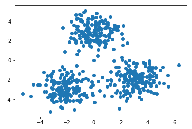

```python
plt.scatter(data[:, 0], data[:, 1])
```

$$\sum_{k}\sum_{i} r_{ik} \|x_i - \mu_k\|^2$$

where $r_{ik}$ is the indicator of where $x_i$ is in class $C_k$.

## K-Means Clustering

Given $K$, K-Means algorithm works as follows,

1. Randomly initialize $K$ centers $\mu_1, \mu_2, \cdots, \mu_k$
2. Iteratively assign each $x_i$ to its nearest center $\mu_k$, and then reestimate $\mu_k$ based on assignment until converge.

**Exercise 0:** First, we will implement the `assign` function, which assigns data points to its nearest center. For example, suppose `data = [[101, 0], [99,1], [-100,2]], mu = [[100,0], [-100, 0]]`, then you would expect to return `membership = [0, 0, 1]`. If there are multiple centers that are equidistant to a point, pick the center with the lowest index, i.e., the first center in mu that is nearest to the point. (3 points)

```python
# this is the data
test_data = [[101, 0],
             [99, 1],
             [-100,2]]

# these are the randomly initialized centroids
test_mu = [[100, 0],
           [-100, 0]]
```

```python
def calculate_euclidean_distance (point_a, point_b):
    diffs = np.subtract(point_a, point_b)
    square_diff = [diff**2 for diff in diffs]
    return np.sqrt(np.sum(square_diff))
```

```python
# d = [101, 0] vs. mu =[100, 0] (class 0)
# closest to class 0, therefore membership should be 0
calculate_euclidean_distance(test_data[0], test_mu[0])
```

```
1.0
```

```python
# d = [101, 0] vs. mu = [-100, 0] (class 1)
calculate_euclidean_distance(test_data[0], test_mu[1])
```

```
201.0
```

```python
# d = [99, 1] vs. mu = [100,0] (class 0)
# closest to class 0, therefore membership should be 0
calculate_euclidean_distance(test_data[1], test_mu[0])
```

```
1.4142135623730951
```

```python
# d = [99, 1] vs. mu = [-100, 0] (class 1)
calculate_euclidean_distance(test_data[1], test_mu[1])
```

```
199.00251254695254
```

```python
# d = [-100, 2] vs. mu = [100, 0] (class 0)
print(test_data[2], test_mu[0])
calculate_euclidean_distance(test_data[2], test_mu[0])
```

```
[-100, 2] [100, 0]
```

```
200.0099997500125
```

```python
# d = [-100, 2] vs mu = [-100, 0] (class 1)
# closest to class 1
calculate_euclidean_distance(test_data[2], test_mu[1])
```

```
2.0
```

```python
min([200, 2])
```

```
2
```

```python
[200, 2].index(2)
```

```
1
```

```python
def calculate_euclidean_distance (point_a, point_b):
    diffs = np.subtract(point_a, point_b)
    square_diff = [diff**2 for diff in diffs]
    return np.sqrt(np.sum(square_diff))

def assign(data, mu):
    # data: (N, 2) numpy.array
    # mu: (K, 2) numpy.array
    # return: (N,) numpy.array indicating class membership of each data point

    membership = np.zeros(len(data))
    ###
    for i, data_point in enumerate(data):
        distances_per_datapoint = []
        for center in mu:
            distances_per_datapoint.append(calculate_euclidean_distance(data_point, center))

        min_distance = min(distances_per_datapoint)

        membership[i] = distances_per_datapoint.index(min_distance)

    ###
    return membership
```

```python
### Test Cell for Debugging
data1, centers1 = make_data(d, n, 3)
student_membership = assign(data1, centers1)
test_assign(data1, centers1, student_membership)
```

```
'Passed!'
```

```python
###
### AUTOGRADER TEST - DO NOT REMOVE
###
```

Next we implement `re_estimate` function. For each class $C_k$, we reestimate its center as $$\mu_k \gets \frac{1}{\sum_{i=1}^N r_{ik}} \sum_{i}r_{ik}x_i$$

**Exercise 1:** The function should return an array where each element gives the 2-D coordinates for the center of the respective class (3 points)

```python
len(set(student_membership))
```

```
3
```

```python
def re_estimate(data, membership):
     # data: (N, 2) numpy.array
     # membership: (N,) numpy.array indicating class membership of each data point
     # mu: (K, 2) numpy.array

    mu = None
    ###

    # K is the number of classes
    K = len(set(membership))

    new_mus = []
    for i in range(K):

        # Find all points in data that were assigned to cluster i & based on these points,
        # Find the new centroid by taking the average of the points that were assigned to cluster_i
        points_prev_assinged_to_i = [d for d, m in zip(data, membership) if m == i]

        # Ensure we do not have an empty vector
        if points_prev_assinged_to_i:
            child_mu = []
            # Average all of th 1st position of the coordinate through nth position of a data point
            for j in range(len(points_prev_assinged_to_i[0])):
                points_to_avg = [point[j] for point in points_prev_assinged_to_i]
                child_mu.append(np.mean(points_to_avg))
            print(child_mu)

            new_mus.append(child_mu)

    mu = np.array(new_mus)
    ###
    return mu
```

```python
### Test Cell for Debugging

data1, centers1 = make_data(d, n, 3)
membership1 = inst_assign(data1, centers1)
student_mu = re_estimate(data1, membership1)
test_re_estimate(data1, membership1, student_mu)
```

```
[-2.124428123480873, -3.0059383824950623]
[3.0682266321160827, -1.9631454698697017]
[0.16831699283872434, 3.0767091370966826]
```

```
'Passed!'
```

```python
###
### AUTOGRADER TEST - DO NOT REMOVE
###
```

Let's put the pieces together and see how well it works.

[output not shown]

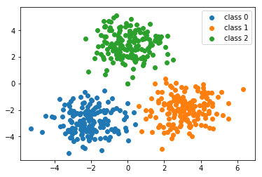

```python
K = 3
mu = centers + 0.5 * np.random.randn(K, d)
max_iter = 20

for it in range(max_iter):
    membership = assign(data, mu)
    mu = re_estimate(data, membership)

for k in range(K):
    mask = membership == k
    x, y = data[mask, 0], data[mask, 1]
    plt.scatter(x, y, label='class {}'.format(k))

plt.legend()
```

## Kernel Density Estimation

We turn our attention to another question, what is the probability distribution of data? A powerful method is kernel density estimation (KDE). The probability density function is given by $$ f(x) = \sum_{i=1}^N \frac{1}{N}K(\frac{x-x_i}{h})$$ where $K(z)=\frac{1}{\sqrt{2\pi}} \exp(-\frac{\|z\|^2}{2})$ is a kernel function and $\|z\|^2$ is the squared euclidean norm). **Hint:** You can use [numpy.linalg.norm](https://docs.scipy.org/doc/numpy/reference/generated/numpy.linalg.norm.html)

**Exercise 2** Implement K(z) based on the above kernel function. Return a numpy array with shape (500,)（2 points)

```python
import numpy.linalg as la
import statsmodels.api as sm
```

```python
my_test_norm = []
for data in data1:
    my_test_norm.append(la.norm(data, 2, keepdims=True))
```

```python
my_test_norm[:10]
```

```
[array([3.04237854]),
 array([4.47468071]),
 array([2.13552176]),
 array([5.4336154]),
 array([4.35060456]),
 array([2.46448456]),
 array([3.82088002]),
 array([3.51188261]),
 array([4.37640214]),
 array([2.58635939])]
```

```python
def kernel(z):
    # z: (N, 2) numpy.array
    # returns (N, 1) numpy.array

    ###
    # Calculate the
    euc_norm = []
    for Z in z:
        euc_norm.append(la.norm(Z, 2, keepdims=False))

    euc_norm_sq = [norm**2 for norm in euc_norm]
    x = [-1*(norm_sq)/2 for norm_sq in euc_norm_sq]

    K_numer = [np.exp(X) for X in x]
    K_denom = np.sqrt(2*np.pi)

    return np.array([num/K_denom for num in K_numer])
    ###
```

```python
### Test Cell for Debugging
data1, centers1 = make_data(d, n, 3)
student_kernel = kernel(data1)
test_kernel(data1, student_kernel)
```

```
'Passed!'
```

```python
###
### AUTOGRADER TEST - DO NOT REMOVE
###
```

**Exercise 3** Based on the KDE function: $$ f(x) = \sum_{i=1}^N \frac{1}{N}K(\frac{x-x_i}{h})$$ Compute the probablity density at `[0,0]`, i.e., $f((0,0))$. This should return a **scalar** value. (2 points）

```python
def compute(data, h):
    ###
    N = len(data)

    ###
```

[output not shown]

```python
### Test Cell for Debugging

data1, centers1 = make_data(d, n, 3)
student_compute = compute(data1, h=1)
test_compute(data1, student_compute, 1)
```

[output not shown]

```python
###
### AUTOGRADER TEST - DO NOT REMOVE
###
```

Finally, use the nice visualization library `seaborn` in Python to visualize the kernel density estimation.

```python
sns.set_style("darkgrid")
colors = ['Reds', 'Blues', 'Greens']

for k in range(K):
    mask = membership == k
    x, y = data[mask, 0], data[mask, 1]
    sns.kdeplot(x, y,
                cmap=colors[k], shade=True, shade_lowest=False)
```

[output not shown]

**Fin!** You've reached the end of this problem. Don't forget to restart the kernel and run the entire notebook from top-to-bottom to make sure you did everything correctly. If that is working, try submitting this problem. (Recall that you *must* submit and pass the autograder to get credit for your work!)